# Recipe Rating Analysis: Nutritional Values and Ingredients

### 3.2.2 Calories - Boxplot and Histogram

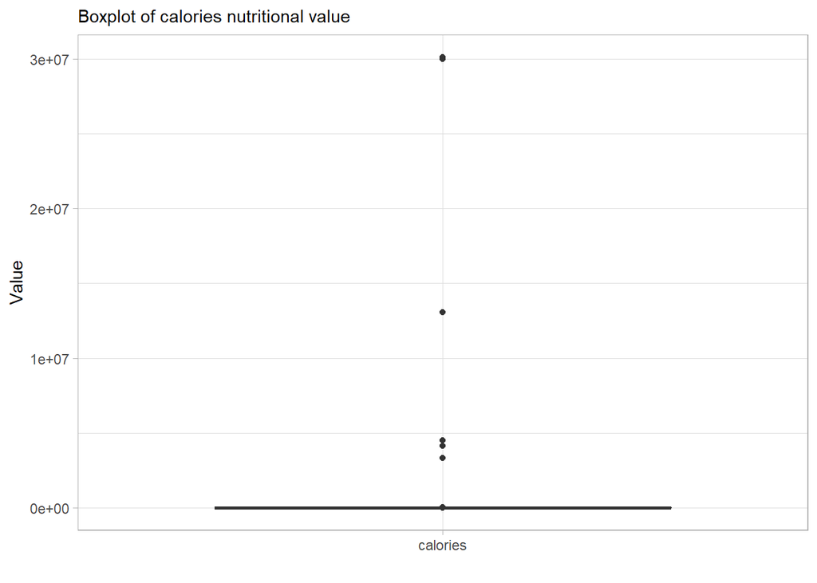

```r
recipes_boxplot <-
  recipes %>%
  pivot_longer(cols = c(calories, protein, fat, sodium),
               names_to = "nutrition",
               values_to = "n_value")

recipes_calories <- recipes_boxplot %>%
  filter(nutrition == "calories")

recipes_calories %>%
  ggplot(aes(x=nutrition, y=n_value, fill=nutrition)) +
    geom_boxplot() +
    scale_fill_viridis(discrete = TRUE, alpha=0.6, option="A") +
    theme_light() +
    theme(legend.position="none",
          plot.title = element_text(size=11)) +
  ggtitle("Boxplot of calories nutritional value") +
  xlab("") +
  ylab("Value")
```

```r
# We notice that there are recipes with more than 30'000'000 calories which are clearly outliers. We must then discard those values in order to continue with a meaningful analysis. Otherwise from a visual point of view we could not extract any relevant information. If we take out these recipes, we still have roughly 30 recipes which have more than 7000 calories. For the purpose of this precise visualisation, we want to exclude them to have a better overview of the boxplot, but we don't consider those as outliers.

recipes_calories %>%
  select(title, nutrition, n_value) %>%
  arrange(desc(n_value))
```

```
#> # A tibble: 10,321 x 3
#>    title                                              nutri~1 n_value
#>    <chr>                                              <chr>     <dbl>
#>  1 "Pear-Cranberry Mincemeat Lattice Pie "            calori~  3.01e7
#>  2 "Deep-Dish Wild Blueberry Pie "                    calori~  3.00e7
#>  3 "Apricot, Cranberry and Walnut Pie "               calori~  1.31e7
#>  4 "Lamb Köfte with Tarator Sauce "                   calori~  4.52e6
#>  5 "Rice Pilaf with Lamb, Carrots, and Raisins "      calori~  4.16e6
#>  6 "Chocolate-Almond Pie "                            calori~  3.36e6
#>  7 "Caramelized Apple and Pear Pie "                  calori~  3.36e6
#>  8 "Merguez Lamb Patties with Golden Raisin Couscous~ calori~  5.45e4
#>  9 "Grilled Lamb Chops with Porcini Mustard "         calori~  2.41e4
#> 10 "Braised Short Ribs with Red Wine Gravy "          calori~  1.96e4
#> # ... with 10,311 more rows, and abbreviated variable name
#> #   1: nutrition
```

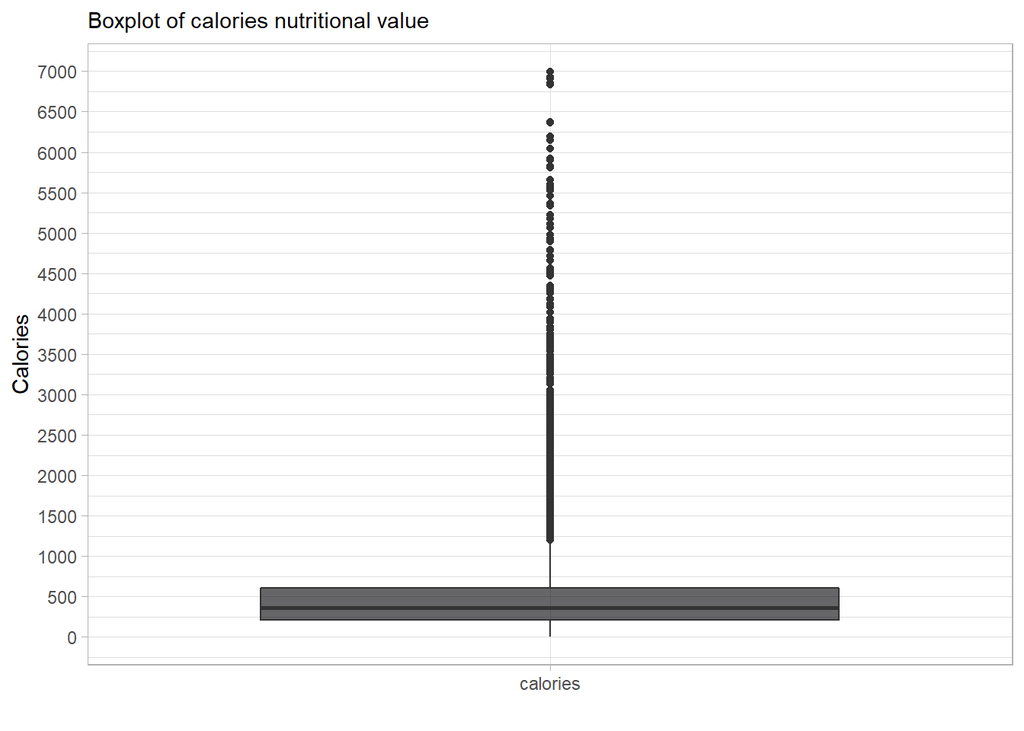

```r
recipes_calories <- recipes_calories %>%
  filter(n_value <= 7000)


# Calories boxplot

recipes_calories %>%
  ggplot(aes(x=nutrition, y=n_value, fill=nutrition)) +
    geom_boxplot() +
    scale_fill_viridis(discrete = TRUE, alpha=0.6, option="A") +
    theme_light() +
    theme(legend.position="none",
          plot.title = element_text(size=11)) +
  scale_y_continuous(breaks=seq(0,7000,500)) +
  ggtitle("Boxplot of calories nutritional value") +
  xlab("") +
  ylab("Calories")
```

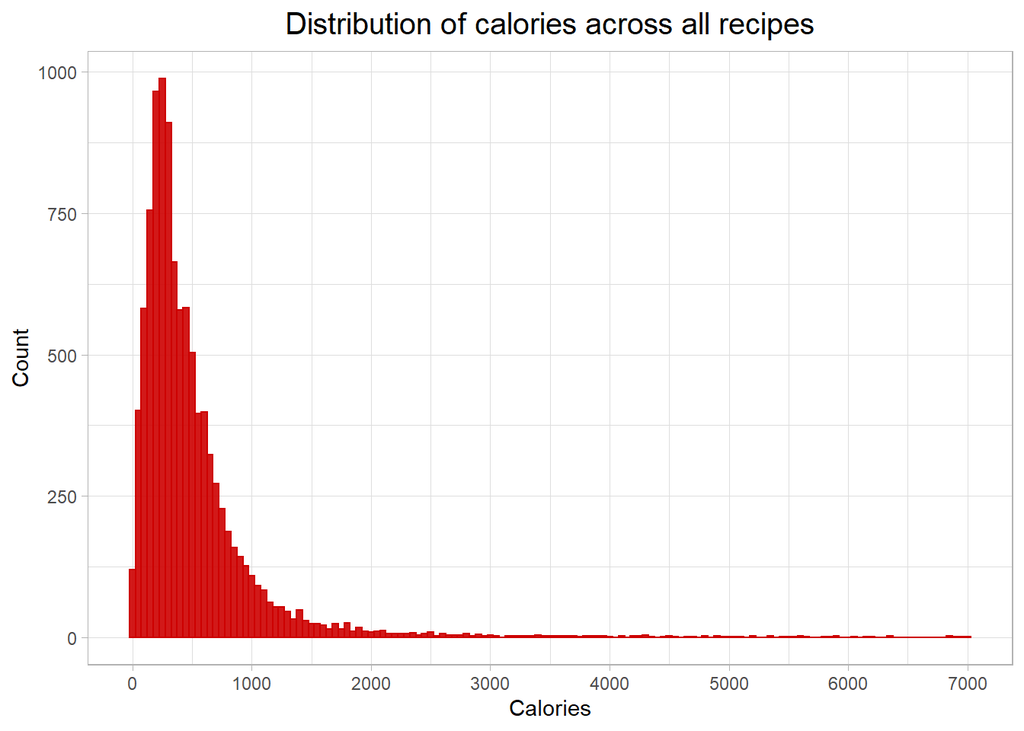

```r
# Calories histogram

recipes_calories %>%
  ggplot(aes(x=n_value)) +
  geom_histogram(binwidth=50, fill="red3", color="red3", alpha=0.9) +
  theme(plot.title = element_text(size=15)) +
  scale_x_continuous(breaks=seq(0,10000,1000)) +
  scale_y_continuous(breaks=seq(0,1750,250)) +
  ggtitle("Distribution of calories across all recipes") +
  xlab("Calories") +
  ylab("Count")
```

We can observe that most of the recipes have between 200 and 600 calories. By checking with the histogram the distribution of calories, we observe that indeed most of the recipes have less than 1000 calories.

### 3.2.3 Protein - Boxplot and Histogram

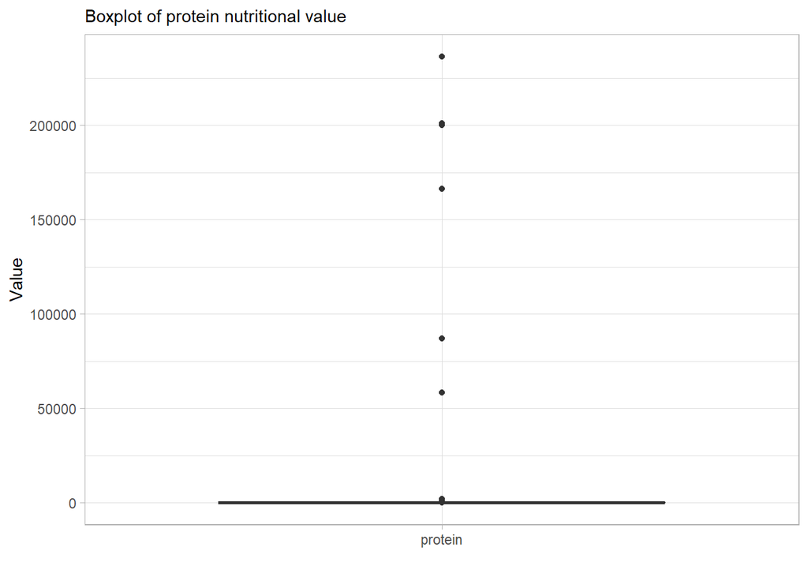

```r
recipes_protein <- recipes_boxplot %>%
  filter(nutrition == "protein")

recipes_protein %>%
  ggplot(aes(x=nutrition, y=n_value, fill=nutrition)) +
    geom_boxplot() +
    scale_fill_viridis(discrete = TRUE, alpha=0.6, option="A") +
    theme_light() +
    theme(legend.position="none",
          plot.title = element_text(size=11)) +
  ggtitle("Boxplot of protein nutritional value") +
  xlab("") +
  ylab("Value")
```

```r
# We notice that there are recipes with more than 50'000 grams of protein which are clearly outliers. We must then discard those values in order to continue with a meaningful analysis. Otherwise from a visual point of view we could not extract any relevant information. By checking on the epicurious website recipes  with protein values above 1000, we also verified that the amount of proteins was not justified. We came to that conclusion by evaluating the average values of protein per 100grams of each ingredient in the specific recipe.

recipes_protein %>%
  select(title, nutrition, n_value) %>%
  arrange(desc(n_value))
```

```
#> # A tibble: 10,321 x 3
#>    title                                              nutri~1 n_value
#>    <chr>                                              <chr>     <dbl>
#>  1 "Rice Pilaf with Lamb, Carrots, and Raisins "      protein  236489
#>  2 "Pear-Cranberry Mincemeat Lattice Pie "            protein  200968
#>  3 "Deep-Dish Wild Blueberry Pie "                    protein  200210
#>  4 "Lamb Köfte with Tarator Sauce "                   protein  166471
#>  5 "Apricot, Cranberry and Walnut Pie "               protein   87188
#>  6 "Chocolate-Almond Pie "                            protein   58334
#>  7 "Caramelized Apple and Pear Pie "                  protein   58324
#>  8 "Merguez Lamb Patties with Golden Raisin Couscous~ protein    2074
#>  9 "Manhattan Clam Chowder "                          protein    1625
#> 10 "Clam and Oyster Chowder "                         protein    1365
#> # ... with 10,311 more rows, and abbreviated variable name
#> #   1: nutrition
```

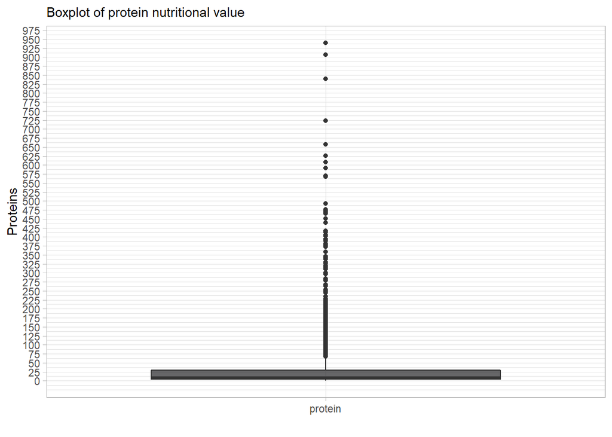

```r
recipes_protein <- recipes_protein %>%
  filter(n_value <= 1000)


# Proteins boxplot

recipes_protein %>%
  ggplot( aes(x=nutrition, y=n_value, fill=nutrition)) +
    geom_boxplot() +
    scale_fill_viridis(discrete = TRUE, alpha=0.6, option="A") +
    theme_light() +
    theme(legend.position="none",
          plot.title = element_text(size=11)) +
  scale_y_continuous(breaks=seq(0,7000,25)) +
  ggtitle("Boxplot of protein nutritional value") +
  xlab("") +
  ylab("Proteins")
```

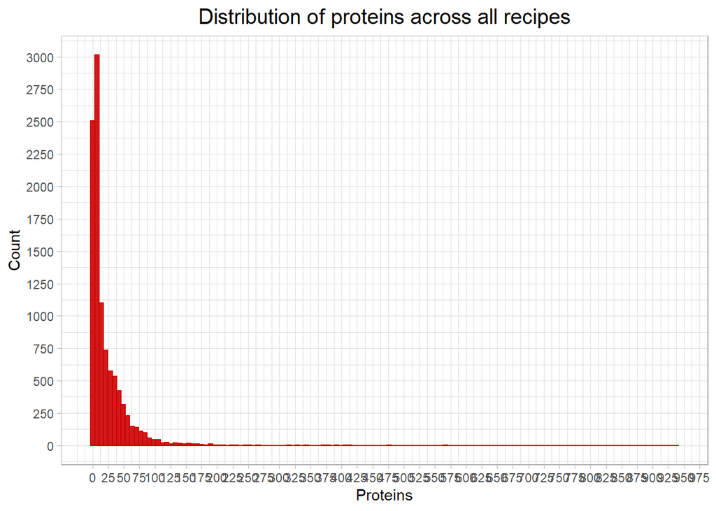

```r
# Proteins histogram

recipes_protein %>%
  ggplot(aes(x=n_value)) +
  geom_histogram(binwidth=7, fill="red3", color="red3", alpha=0.9) +
  theme(plot.title = element_text(size=15)) +
  scale_x_continuous(breaks=seq(0,1000,25)) +
  scale_y_continuous(breaks=seq(0,7000,250)) +
  ggtitle("Distribution of proteins across all recipes") +
  xlab("Proteins") +
  ylab("Count")
```

From the boxplot, we observe that most recipes have less than 30 grams of proteins. By plotting the histogram, we verify that this information is correct. We could even extend the range to 100 proteins per recipe. We assume that recipes with values above this threshold contain ingredients like meat, tuna, salmon or shrimps.

### 3.2.4 Sodium - Boxplot and Histogram

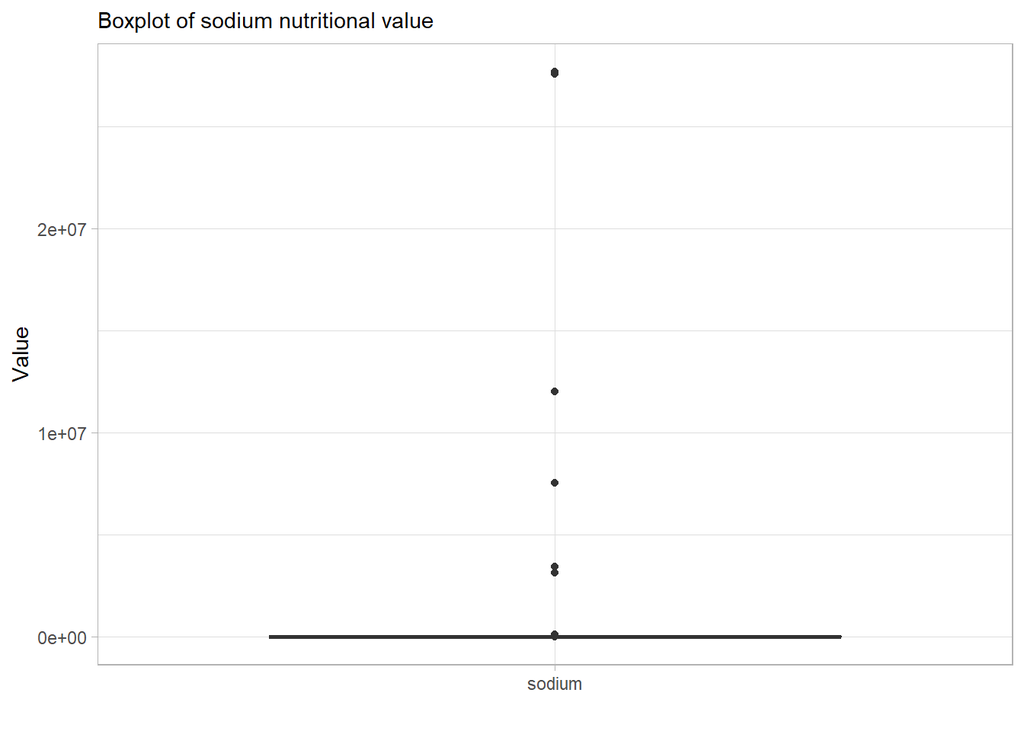

```r
recipes_sodium <- recipes_boxplot %>%
  filter(nutrition == "sodium")

recipes_sodium %>%
  ggplot(aes(x=nutrition, y=n_value, fill=nutrition)) +
    geom_boxplot() +
    scale_fill_viridis(discrete = TRUE, alpha=0.6, option="A") +
    theme_light() +
    theme(legend.position="none",
          plot.title = element_text(size=11)) +
  ggtitle("Boxplot of sodium nutritional value") +
  xlab("") +
  ylab("Value")
```

```r
# We notice that there are recipes with more than 100'000 milligrams of sodium which are clearly outliers. We must then discard those values in order to continue with a meaningful analysis. By conducting further research, we realize that sodium values above 30'000 are highly suspicious.

recipes_sodium %>%
  select(title, nutrition, n_value) %>%
  arrange(desc(n_value))
```

```
#> # A tibble: 10,321 x 3
#>    title                                           nutrition  n_value
#>    <chr>                                           <chr>        <dbl>
#>  1 "Pear-Cranberry Mincemeat Lattice Pie "         sodium    27675110
#>  2 "Deep-Dish Wild Blueberry Pie "                 sodium    27570999
#>  3 "Apricot, Cranberry and Walnut Pie "            sodium    12005810
#>  4 "Lamb Köfte with Tarator Sauce "                sodium     7540990
#>  5 "Chocolate-Almond Pie "                         sodium     3449512
#>  6 "Caramelized Apple and Pear Pie "               sodium     3449373
#>  7 "Rice Pilaf with Lamb, Carrots, and Raisins "   sodium     3134853
#>  8 "Whole Branzino Roasted in Salt "               sodium      132220
#>  9 "Red Snapper Baked in Salt with Romesco Sauce " sodium      132025
#> 10 "Scallops with Mushrooms in White-Wine Sauce "  sodium       90572
#> # ... with 10,311 more rows
```

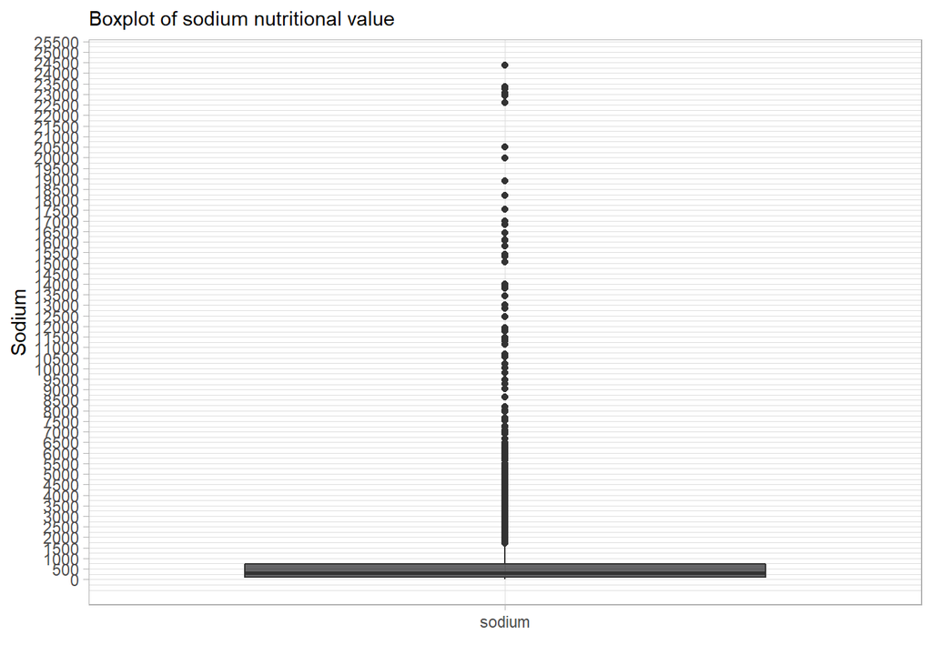

```r
recipes_sodium <- recipes_sodium %>%
  filter(n_value <= 30000)


# Sodium boxplot

recipes_sodium %>%
  ggplot(aes(x=nutrition, y=n_value, fill=nutrition)) +
    geom_boxplot() +
    scale_fill_viridis(discrete = TRUE, alpha=0.6, option="A") +
    theme_light() +
    theme(legend.position="none",
          plot.title = element_text(size=11)) +
  scale_y_continuous(breaks=seq(0,30000,500)) +
  ggtitle("Boxplot of sodium nutritional value") +
  xlab("") +
  ylab("Sodium")
```

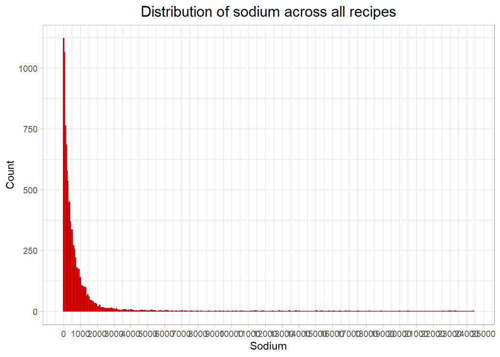

```r
# Sodium histogram

recipes_sodium %>%
  ggplot(aes(x=n_value)) +
  geom_histogram(binwidth=50, fill="red3", color="red3", alpha=0.9) +
  theme(plot.title = element_text(size=15)) +
  scale_x_continuous(breaks=seq(0,30000,1000)) +
  scale_y_continuous(breaks=seq(0,1750,250)) +
  ggtitle("Distribution of sodium across all recipes") +
  xlab("Sodium") +
  ylab("Count")
```

From the boxplot we observe that most recipes have sodium values below 750 milligrams. The histogram informs us that most of recipes have indeed less than 750 milligrams of sodium, even though we cannot exclude the presence of a good amount of recipes with sodium between 750 and 2000 milligrams.

### 3.2.5 Fat - Boxplot and Histogram

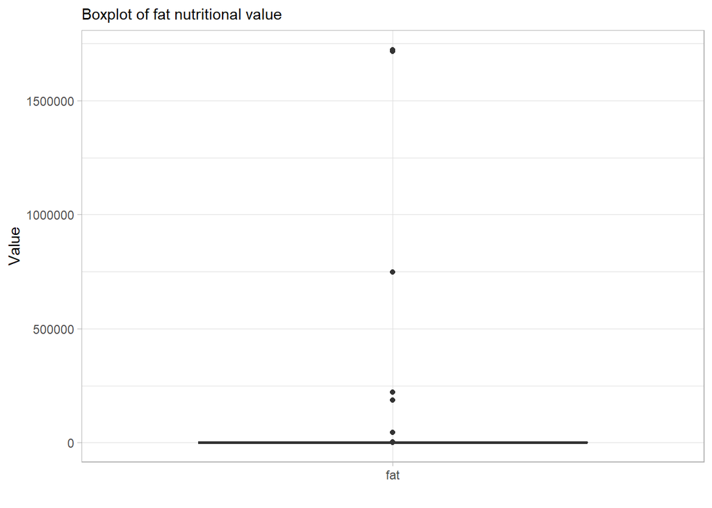

```r
recipes_fat <- recipes_boxplot %>%
  filter(nutrition == "fat")

recipes_fat %>%
  ggplot(aes(x=nutrition, y=n_value, fill=nutrition)) +
    geom_boxplot() +
    scale_fill_viridis(discrete = TRUE, alpha=0.6, option="A") +
    theme_light() +
    theme(legend.position="none",
          plot.title = element_text(size=11)) +
  ggtitle("Boxplot of fat nutritional value") +
  xlab("") +
  ylab("Value")
```

```r
# We notice that there are recipes with more than 44'000 grams of fat which are clearly outliers. We must then discard those values in order to continue with a meaningful analysis. By checking on the epicurious website recipes  with fat values above 1000, we also verified that the amount of proteins was not justified. We came to that conclusion by evaluating the average values of protein per 100grams of each ingredient in the specific recipe.

recipes_fat %>%
  select(title, nutrition, n_value) %>%
  arrange(desc(n_value))
```

```
#> # A tibble: 10,321 x 3
#>    title                                           nutrition n_value
#>    <chr>                                           <chr>       <dbl>
#>  1 "Pear-Cranberry Mincemeat Lattice Pie "         fat       1722763
#>  2 "Deep-Dish Wild Blueberry Pie "                 fat       1716279
#>  3 "Apricot, Cranberry and Walnut Pie "            fat        747374
#>  4 "Rice Pilaf with Lamb, Carrots, and Raisins "   fat        221495
#>  5 "Chocolate-Almond Pie "                         fat        186660
#>  6 "Caramelized Apple and Pear Pie "               fat        186642
#>  7 "Lamb Köfte with Tarator Sauce "                fat         44198
#>  8 "Grilled Lamb Chops with Porcini Mustard "      fat          2228
#>  9 "Braised Short Ribs with Red Wine Gravy "       fat          1818
#> 10 "Braised Duck Legs with Shallots and Parsnips " fat          1610
#> # ... with 10,311 more rows
```

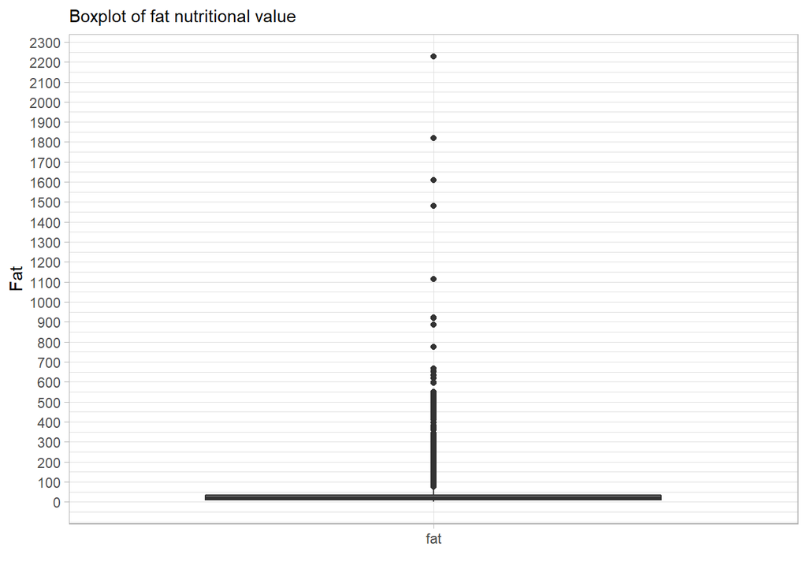

```r
recipes_fat <- recipes_fat %>%
  filter(n_value <= 40000)


# Fat boxplot

recipes_fat %>%
  ggplot( aes(x=nutrition, y=n_value, fill=nutrition)) +
    geom_boxplot() +
    scale_fill_viridis(discrete = TRUE, alpha=0.6, option="A") +
    theme_light() +
    theme(legend.position="none",
          plot.title = element_text(size=11)) +
  scale_y_continuous(breaks=seq(0,3000,100)) +
  ggtitle("Boxplot of fat nutritional value") +
  xlab("") +
  ylab("Fat")
```

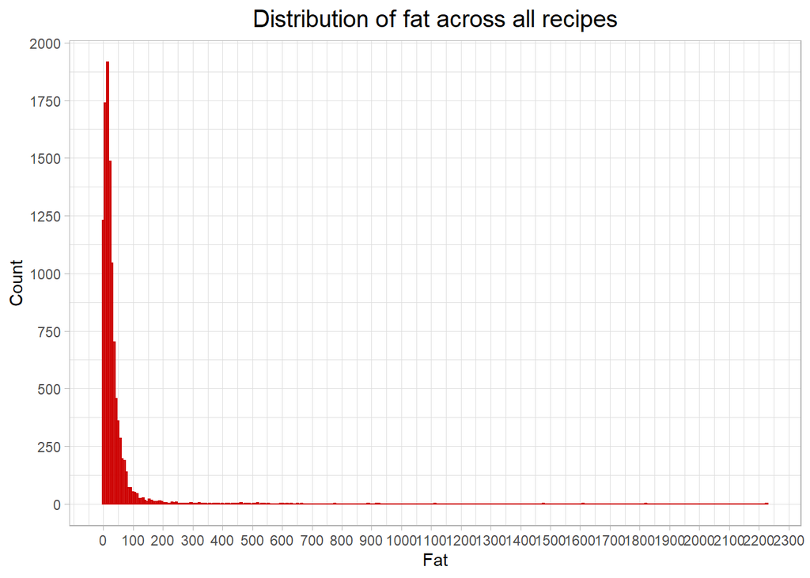

```r
# Fat histogram

recipes_fat %>%
  ggplot(aes(x=n_value)) +
  geom_histogram(binwidth=7, fill="red3", color="red3", alpha=0.9) +
  theme(plot.title = element_text(size=15)) +
  ggtitle("Distribution of fat across all recipes") +
  scale_x_continuous(breaks=seq(0,3000,100)) +
  scale_y_continuous(breaks=seq(0,7000,250)) +
  xlab("Fat") +
  ylab("Count")
```

It is hard to interpret the boxplot. There are certain recipes which could have potentially more than 1000 or even 2000 grams of fat because of the high quantity of servings and the use of ingredients such as lamb, duck and bacon. We must then analyse the histogram to have a better overview and we notice that most recipes have fat values below 100 grams.

## 3.3 Visual exploration - Multivariate Analysis

### 3.3.1 Scatterplots of Rating

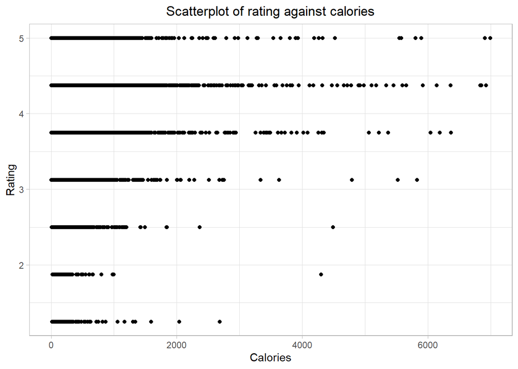

```r
recipes <- recipes %>%
  filter(calories <= 7000, protein <= 1000, sodium <= 30000, fat <= 40000)


# Scatterplot of Rating-Calories
recipes %>%
  ggplot(aes(x=calories, y=rating)) +
  geom_point() +
  ggtitle("Scatterplot of rating against calories") +
  xlab("Calories") +
  ylab("Rating")
```

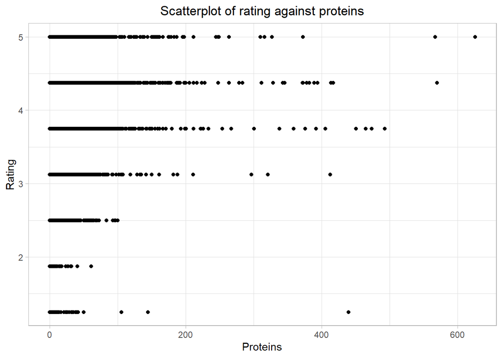

```r
# We can observe that the recipes with more than 2000 calories tend to have a higher rating. For instance, few recipes with less than a 3 star rating have more than 2000 calories.


# Scatterplot of Rating-Protein
recipes %>%
  ggplot(aes(x=protein, y=rating)) +
  geom_point() +
  ggtitle("Scatterplot of rating against proteins") +
  xlab("Proteins") +
  ylab("Rating")
```

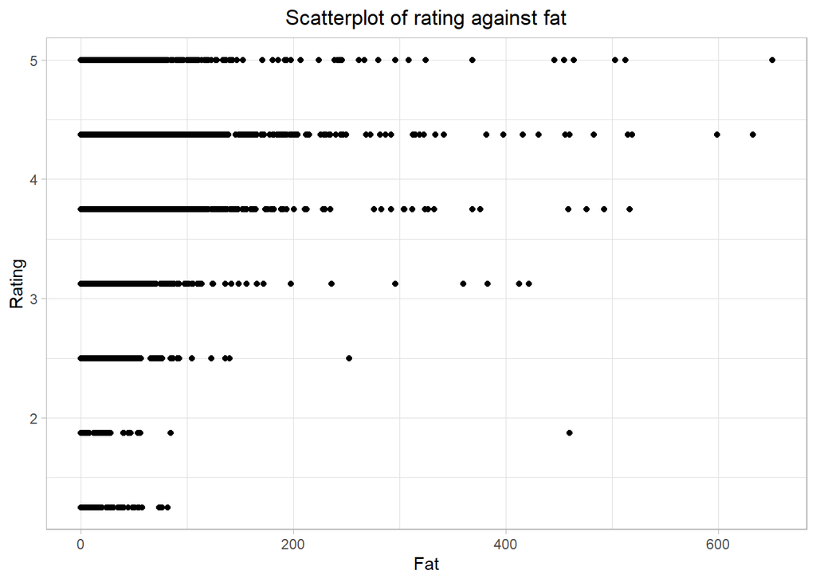

```r
# We can observe that the recipes with more than 125 grams of proteins tend to have a higher rating. For instance, few recipes with less than a 3 star rating have more than 125 grams of proteins.


# Scatterplot of Rating-Fat
recipes %>%
  ggplot(aes(x=fat, y=rating)) +
  geom_point() +
  ggtitle("Scatterplot of rating against fat") +
  xlab("Fat") +
  ylab("Rating")
```

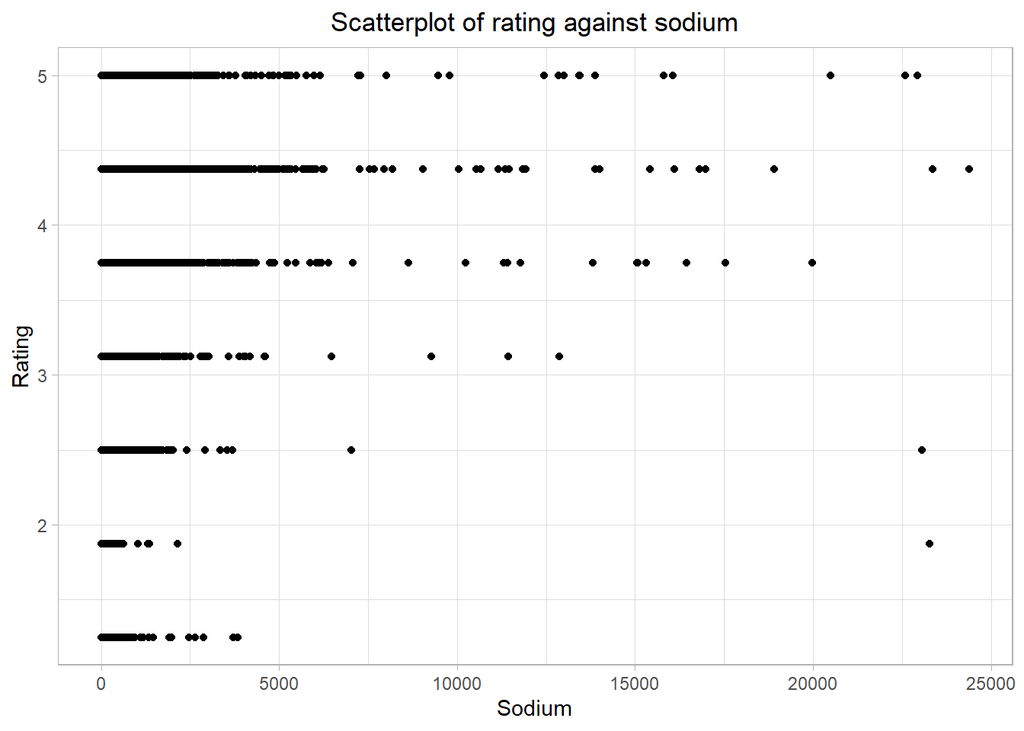

```r
# We can observe that the recipes with more than 100 grams of fat tend to have a higher rating. For instance, few recipes with less than a 3 star rating have more than 100 grams of fat.


# Scatterplot of Rating-Sodium
recipes %>%
  ggplot(aes(x=sodium, y=rating)) +
  geom_point() +
  ggtitle("Scatterplot of rating against sodium") +
  xlab("Sodium") +
  ylab("Rating")
```

```r
# We can observe that the recipes with more than 5000 milligrams of sodium tend to have a higher rating. For instance, few recipes with less than a 3 star rating have more than 5000 mg of sodium.
```

### 3.3.2 Correlogram

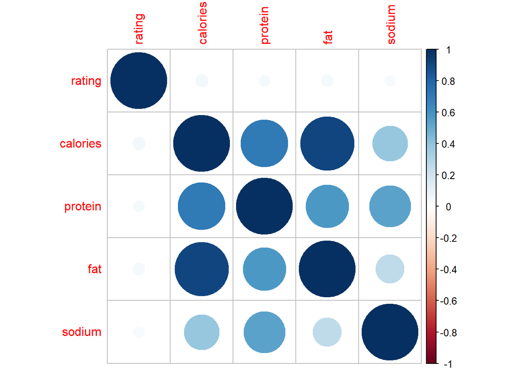

```r
corr_nutritional_values = recipes %>%
  select(rating, calories, protein, fat, sodium) %>%
  cor()

corrplot(corr_nutritional_values)
```

The previous scatterplots illuded us that there was somehow a correlation between rating and the nutritional values. This hypothesis has been refuted because the correlation against the rating is almost at zero for all the nutritional values. On the other hand we notice a strong positive correlation between calories and fat as well as between calories and proteins.

### 3.3.3 Grouped Scatter

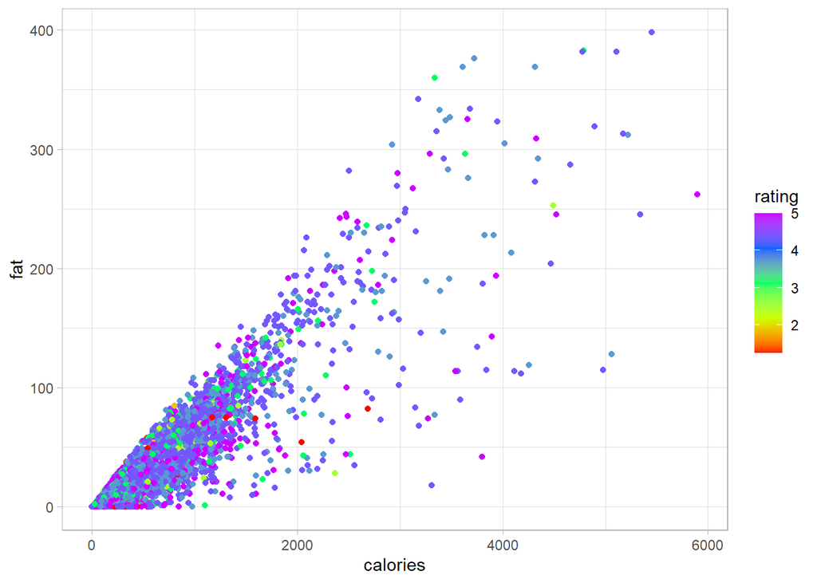

```r
# We decide to plot together the variables which highlight a great level of correlation.

# Grouped scatter of calories and fat
recipes_plot1 <- recipes %>%
  filter(fat <= 400, calories <= 6000)

recipes_plot1 %>%
  ggplot(aes(x=calories, y=fat, color=rating)) +
  geom_point() +
  scale_color_gradientn(colours = rainbow(5))
```

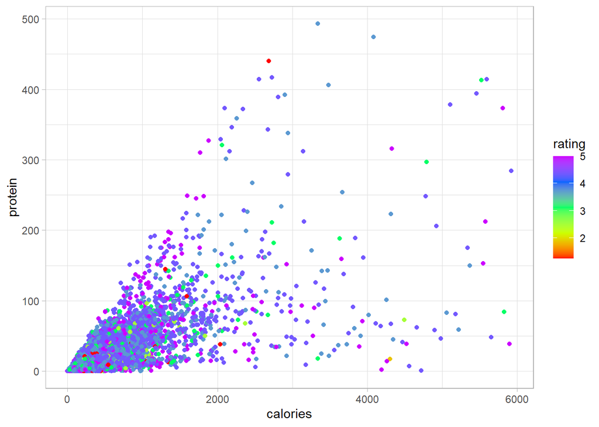

```r
# Grouped scatter of calories and protein
recipes_plot2 <- recipes %>%
  filter(protein <= 500, calories <= 6000)

recipes_plot2 %>%
  ggplot(aes(x=calories, y=protein, color=rating)) +
  geom_point() +
  scale_color_gradientn(colours = rainbow(5))
```

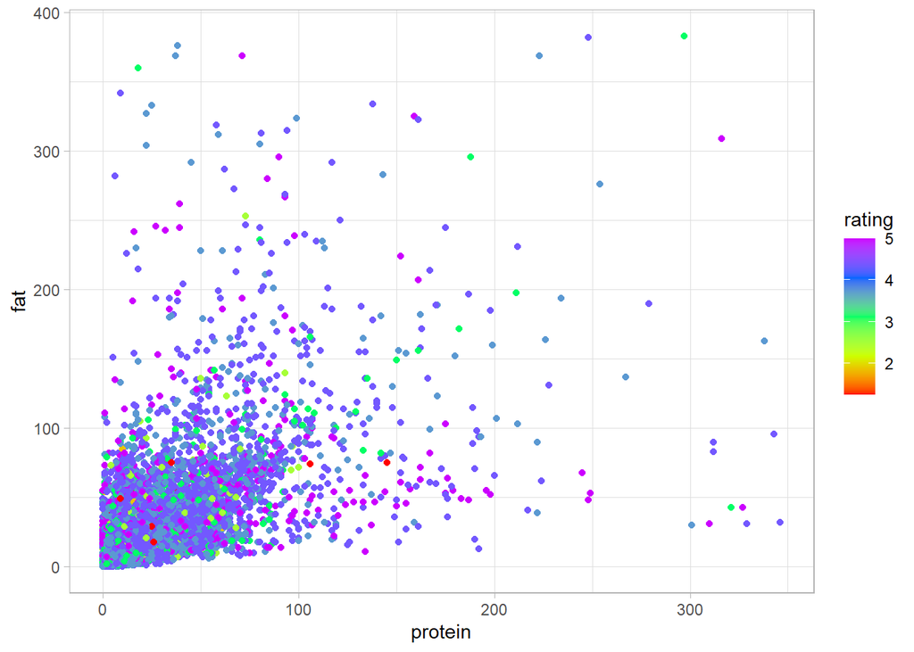

```r
# Grouped scatter of protein and fat
recipes_plot3 <- recipes %>%
  filter(fat <= 400, protein <= 350)

recipes_plot3 %>%
  ggplot(aes(x=protein, y=fat, color=rating)) +
  geom_point() +
  scale_color_gradientn(colours = rainbow(5))
```

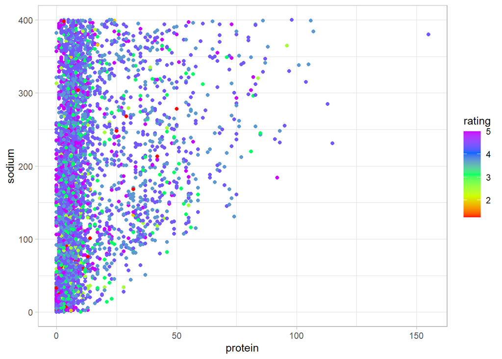

```r
# Grouped scatter of protein and sodium
recipes_plot4 <- recipes %>%
  filter(sodium <= 400, protein <= 350)

recipes_plot4 %>%
  ggplot(aes(x=protein, y=sodium, color=rating)) +
  geom_point() +
  scale_color_gradientn(colours = rainbow(5))
```

# 4 Ingredients EDA

## 4.1 Feature engineering

```r
#Creating a new dataframe with only the ID, title and the ingredients

#through the analysis above, we saw that "drinks" on it's own had only 11 observations, 4 of which also had the value "drink" = 1 --> we decided to merge the two columns to simplify working with a single category called "drink" for all drinks
ingredients_df <- recipes %>%
  mutate(drink = ifelse(drink == 1 | drinks == 1, 1, 0)) %>% #merging drinks and drink
  select(ID, title, all_of(all_ingredients), rating)
```

### 4.1.1 Adding binary columns

```r
#doing it manually, could implement a for loop but not sure I'd gain much time
ingredients_df_bin <- ingredients_df %>%
  mutate(vegetables_bin = as.numeric(if_any(all_of(vegetables_vec), ~.x == 1, na.rm = TRUE)),#first for categories with a general variable
         meats_bin = as.numeric(if_any(all_of(all_meats), ~.x == 1, na.rm = TRUE)),
         fish_bin = as.numeric(if_any(all_of(fish_vec), ~.x == 1, na.rm = TRUE)),
         seafood_bin = as.numeric(if_any(all_of(seafood_vec), ~.x == 1, na.rm = TRUE)),
         herbs_bin = as.numeric(if_any(all_of(herbs_vec), ~.x == 1, na.rm = TRUE)),
         nuts_bin = as.numeric(if_any(all_of(nuts_vec), ~.x == 1, na.rm = TRUE)),
         fruits_bin = as.numeric(if_any(all_of(fruits_vec), ~.x == 1, na.rm = TRUE)),
         #drinks_bin = as.numeric(if_any(all_of(drink_no_alcohol_vec), ~.x == 1, na.rm = TRUE)),
         cheese_bin = as.numeric(if_any(all_of(cheeses_vec), ~.x == 1, na.rm = TRUE)),
         dairy_bin = as.numeric(if_any(all_of(dairy_vec), ~.x == 1, na.rm = TRUE)),
         spices_bin = as.numeric(if_any(all_of(spices_vec), ~.x == 1, na.rm = TRUE)),
         cereals_bin = as.numeric(if_any(all_of(cereals_vec), ~.x == 1, na.rm = TRUE)),#now for the other categories which don't have a general variable
         carbs_bin = as.numeric(if_any(all_of(carbs_vec), ~.x == 1, na.rm = TRUE)),
         dessert_bin = as.numeric(if_any(all_of(dessert_vec), ~.x == 1, na.rm = TRUE)),
         egg_bin = (egg)
         )
```

The fact that both select the same number of rows makes having general categories redundant in the dataset. They are not useful to create the binary columns, and they are also not useful to compute the total amount of ingredients in each category per recipe –> let’s just not include them in the first place

```r
####testing if I still need to include the general category to create the binary column now that I modified the df to only include recipes with ingredients specified
#
# #6586
# ingredients_df %>%
#   mutate(vegetables_bin = as.factor(as.numeric(if_any(c(vegetable, all_of(vegetables_vec)), ~.x == 1, na.rm = TRUE)))) %>%
#   filter(vegetables_bin == 1)
#
# #6586
# ingredients_df %>%
#   mutate(vegetables_bin = as.factor(as.numeric(if_any(all_of(vegetables_vec), ~.x == 1, na.rm = TRUE)))) %>%
#   filter(vegetables_bin == 1)
```

### 4.1.2 Adding total columns

```r
ingredients_df_total <- ingredients_df %>%
  mutate(total_ingredients = rowSums(select(., c(all_of(all_ingredients)))),
         total_vegetables = rowSums(select(., c(all_of(vegetables_vec)))),
         total_meat = rowSums(select(., c(all_of(all_meats)))),
         total_fish = rowSums(select(., c(all_of(fish_vec)))),
         total_seafood = rowSums(select(., c(all_of(seafood_vec)))),
         total_herbs = rowSums(select(., c(all_of(herbs_vec)))),
         total_nuts = rowSums(select(., c(all_of(nuts_vec)))),
         total_fruits = rowSums(select(., c(all_of(fruits_vec)))),
         #total_drinks = rowSums(select(., c(all_of(drink_no_alcohol_vec)))),
         total_cheese = rowSums(select(., c(all_of(cheeses_vec)))),
         total_dairy= rowSums(select(., c(all_of(dairy_vec)))),
         total_spices= rowSums(select(., c(all_of(spices_vec)))),
         total_cereals= rowSums(select(., c(all_of(cereals_vec)))),
         total_carbs = rowSums(select(., c(all_of(carbs_vec)))),
         total_dessert = rowSums(select(., c(all_of(dessert_vec))))
         ) %>%
  select(ID, title, contains("total"), everything())
```

```r
total_join <- ingredients_df_total %>%
  select(ID, contains("total"))

ingredients_df_full <- ingredients_df_bin %>%
  left_join(total_join)
```

## 4.2 Analysis part - Within ingredients

### 4.2.1 Frequency of ingredients - binary columns categories

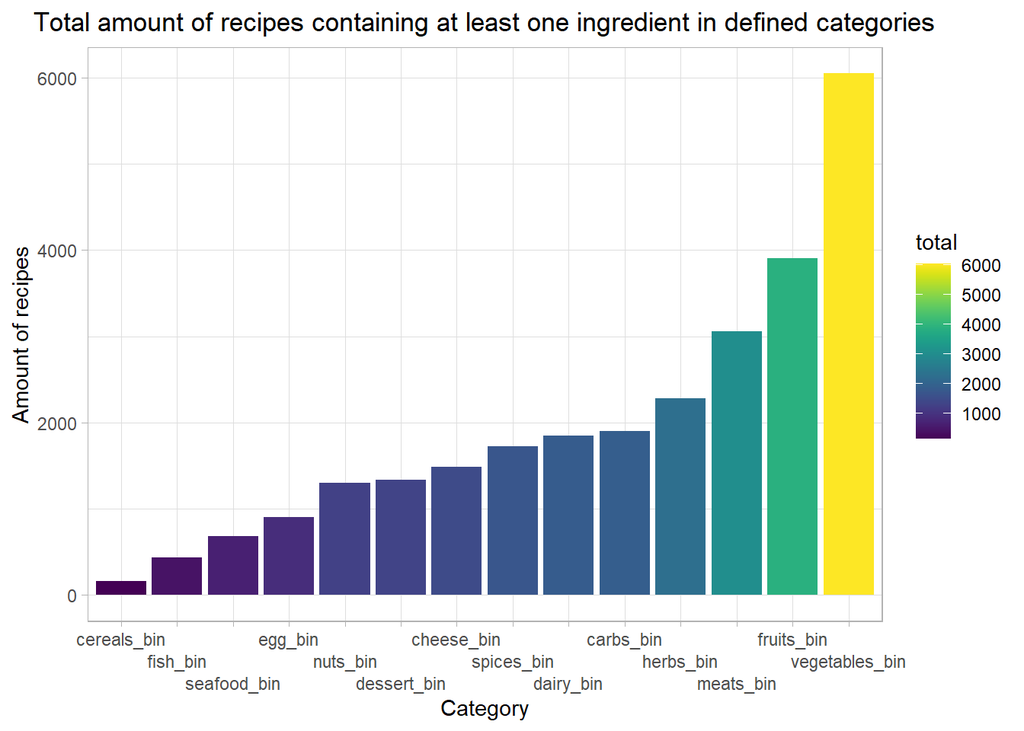

```r
#creating a vector with colnames of all the binary columns to be able to select them more easily afterwards
binary_columns <- ingredients_df_bin %>%
  select(contains("bin")) %>%
  colnames()

#adding binary columns to ingredients_df
total_categories <- ingredients_df_bin %>%
  select(ID, all_of(binary_columns)) %>%
  pivot_longer(-ID, names_to = "category", values_to = "binary_value") %>%
  group_by(category) %>%
  summarise(total = sum(binary_value))

#plotting the frequency of binary columns
total_categories %>%
  ggplot(aes(x=reorder(category,total), y=total, fill=total)) +
  geom_bar(stat = "identity") +
  scale_x_discrete(guide = guide_axis(n.dodge=3))+
  scale_fill_viridis() +
  labs(x = "Category", y = "Amount of recipes", title = "Total amount of recipes containing at least one ingredient in defined categories")
```

The below boxplots give us similar information about the amount of recipe which contain at least one ingredient in each category.The only category for which the an ingredient is present at least ince in more than 50% of the recipes is vegetables.

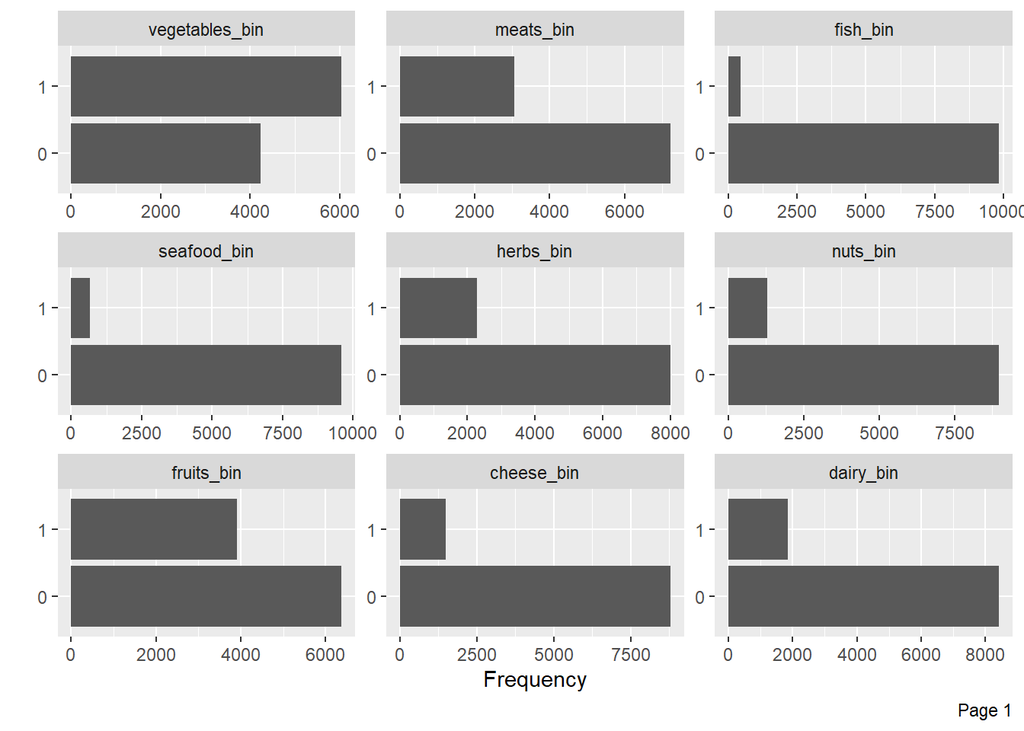

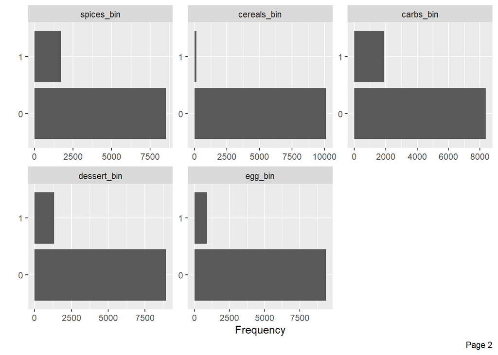

```r
ingredients_df_bin %>%
  select(contains("bin")) %>%
  mutate(across(everything(), as.factor)) %>%
  plot_bar(order_bar = FALSE)
```

### 4.2.2 Correlation between binary columns, including the rating

We can see that no binary variable correlated to the rating in any way.

We see some somewhat strong negative correlation between vegetables and dessert, and between vegetable and fruits. This makes sense, as these ingredients are rarely found together in recipes. As a side note, we chose to classify tomato as a vegetable and strongly stand by this opinion :)

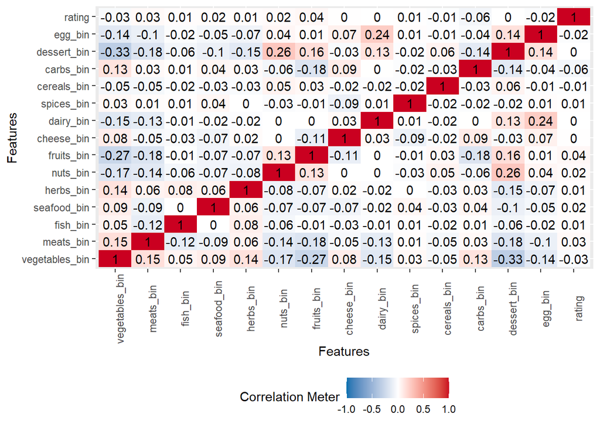

```r
ingredients_df_bin %>%
  select(contains("bin"), rating) %>%
  plot_correlation()
```

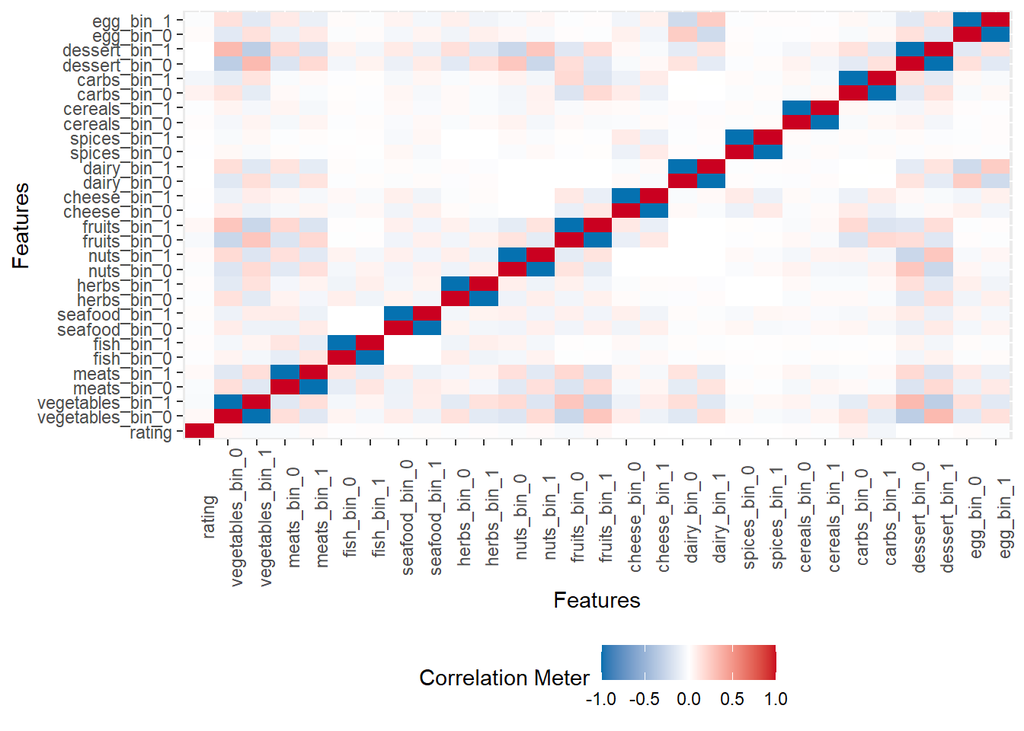

```r
#testing if corr matrix changes when we set the binary columns as factor instead of num
ingredients_df_bin %>%
  select(contains("bin"), rating) %>%
  mutate(across(-rating, as.factor)) %>%
  plot_correlation()
```

```r
#this gives weird results
```

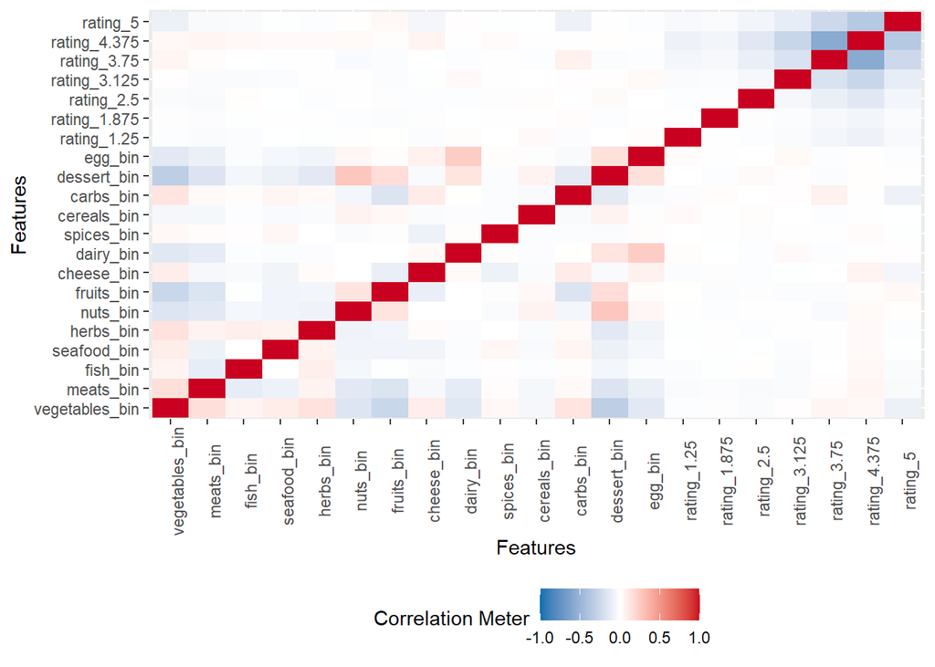

```r
#now trying with rating as a factor
ingredients_df_bin %>%
  select(contains("bin"), rating) %>%
  mutate(across(rating, as.factor)) %>%
  plot_correlation()
```

### 4.2.3 Total individual ingredients

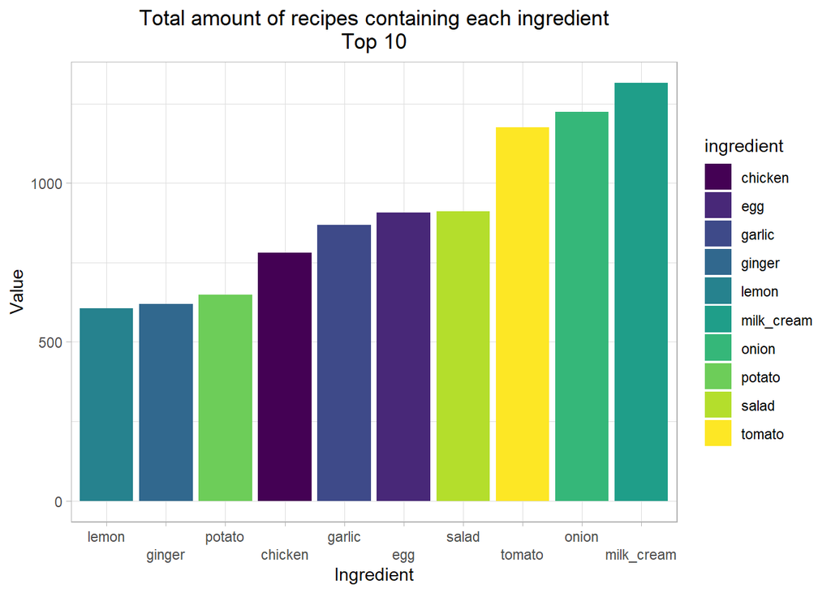

```r
#Analysis which single ingredient is present in most recipes
df <- ingredients_df %>%
  select(-title, -rating) %>%
  pivot_longer(-ID, names_to = "ingredient", values_to = "value")


ing_top10 <- df %>%
  group_by(ingredient) %>%
  summarise(total = sum(value)) %>%
  ungroup() %>%
  arrange(desc(total)) %>%
  slice(1:10)

ing_top10 %>%
  # mutate(ingredient = fct_rev(ingredient)) %>%
  ggplot(aes(x=reorder(ingredient, total), y=total, fill=ingredient)) +
  geom_bar(stat = "identity") +
  scale_fill_viridis(discrete = TRUE) +
  scale_x_discrete(guide = guide_axis(n.dodge=2))+
  labs(x = "Ingredient", y = "Value", title = "Total amount of recipes containing each ingredient\nTop 10")
```

### 4.2.4 Correlation between number of ingredients and rating

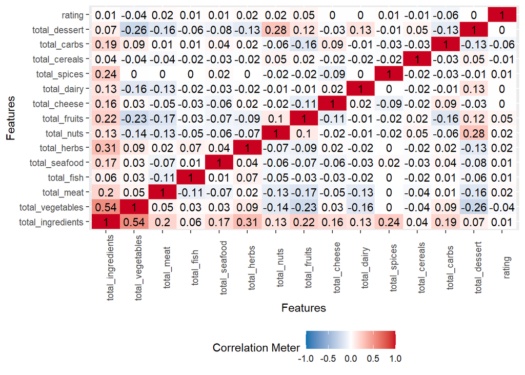

```r
ingredients_df_total %>%
  select(contains("total"), rating) %>%
  plot_correlation()
```